# Back-of-the-Envelope COVID-19 Projections

Benjamin Livingston

March 21, 2020

This is how how COVID-19 growth in the United States looked / looks / is projected to look:  
1) A week ago  
2) Today  
3) A week from now  
4) Two weeks from now

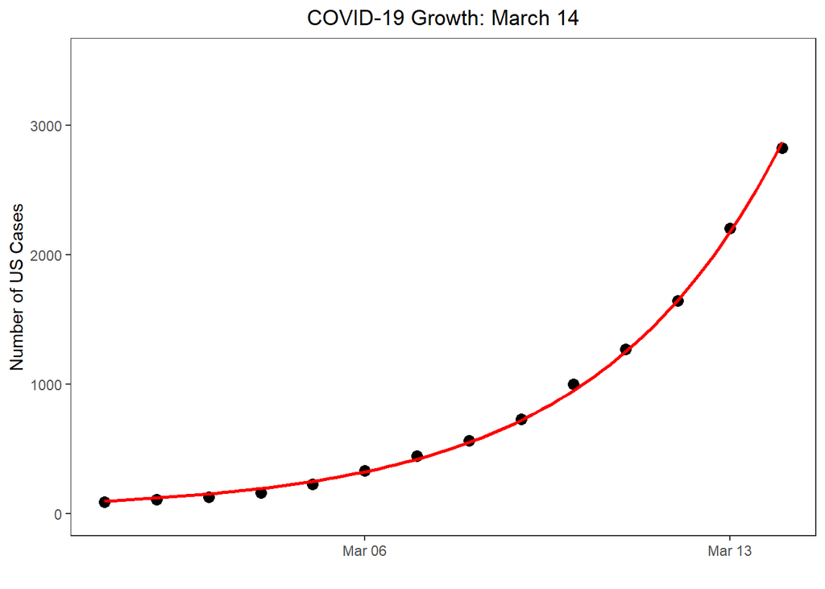

```r
library(lubridate)
library(ggplot2)
library(ggthemes)
data = read.csv('data.csv',sep=':',header=F,stringsAsFactors = F)
names(data) = c('date','no_cases')
data$date = as_date(fast_strptime(data$date, '%m/%d'))
data$no_cases = as.numeric(gsub(',','',data$no_cases))
fit = lm(log(data$no_cases) ~ as.numeric(data$date - min(data$date)))
data = cbind(data,fitted = fitted(fit))
names(data) = c('Date','Number of US Cases','fitted values')

g1 = ggplot(data,aes(x=`Date`,y=`Number of US Cases`)) +
  geom_point(size=3) +
  geom_smooth(method=lm,se=F,fullrange=T,color='red',
              formula =
                y~exp(fit$coefficients[1] +
                        fit$coefficients[2] * as.numeric(as_date(x) - min(data$`Date`)))) +
  xlab('') +
  xlim(c(ymd('0000-03-01'),ymd('0000-03-14'))) +
  ggtitle('COVID-19 Growth: March 14') +
  theme_bw() +
  theme(panel.grid = element_blank(),
        plot.title = element_text(hjust = 0.5)) +
  scale_y_continuous(labels = function(x) format(x, scientific = F,big.mark=',')) +
  ylim(c(0,3500))

g2 = ggplot(data,aes(x=`Date`,y=`Number of US Cases`)) +
  geom_point(size=3) +
  geom_smooth(method=lm,se=F,fullrange=T,color='red',
              formula =
                y~exp(fit$coefficients[1] +
                        fit$coefficients[2] * as.numeric(as_date(x) - min(data$`Date`)))) +
  xlab('') +
  xlim(c(ymd('0000-03-01'),ymd('0000-03-21'))) +
  ylim(c(0,27000)) +
  ggtitle('COVID-19 Growth: March 21') +
  theme_bw() +
  theme(panel.grid = element_blank(),
        plot.title = element_text(hjust = 0.5)) +
  scale_y_continuous(labels = function(x) format(x, scientific = F,big.mark=','))

g3 = ggplot(data,aes(x=`Date`,y=`Number of US Cases`)) +
  geom_point(size=3) +
  geom_smooth(method=lm,se=F,fullrange=T,color='red',
              formula =
                y~exp(fit$coefficients[1] +
                        fit$coefficients[2] * as.numeric(as_date(x) - min(data$`Date`)))) +
  xlab('') +
  xlim(c(ymd('0000-03-01'),ymd('0000-03-28'))) +
  ggtitle('COVID-19 Growth: March 28') +
  theme_bw() +
  theme(panel.grid = element_blank(),
        plot.title = element_text(hjust = 0.5)) +
  scale_y_continuous(labels = function(x) format(x, scientific = F,big.mark=','))

g4 = ggplot(data,aes(x=`Date`,y=`Number of US Cases`)) +
  geom_point(size=3) +
  geom_smooth(method=lm,se=F,fullrange=T,color='red',
              formula =
                y~exp(fit$coefficients[1] +
                        fit$coefficients[2] * as.numeric(as_date(x) - min(data$`Date`)))) +
  xlab('') +
  xlim(c(ymd('0000-03-01'),ymd('0000-04-01'))) +
  ggtitle('COVID-19 Growth: April 4') +
  theme_bw() +
  theme(panel.grid = element_blank(),
        plot.title = element_text(hjust = 0.5)) +
  scale_y_continuous(labels = function(x) format(x, scientific = F,big.mark=','))


g1
```

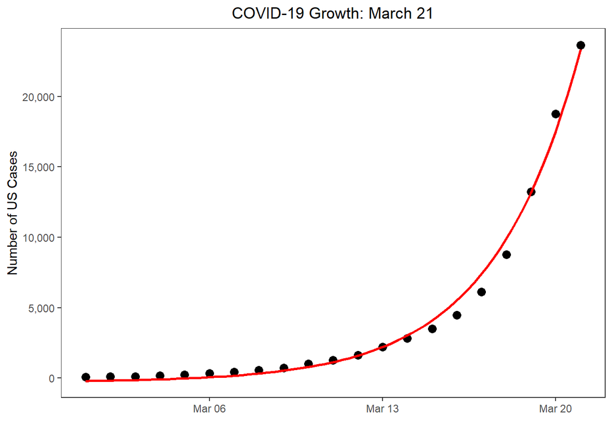

```r
g2
```

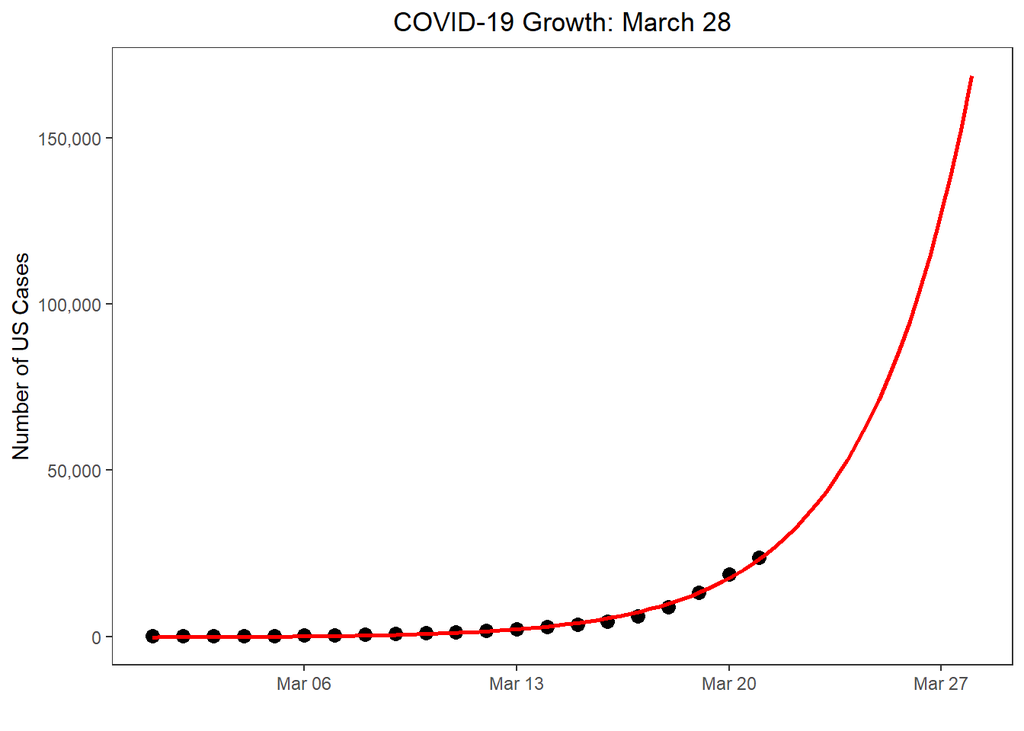

```r
g3
```

[figure not shown]

```r
g4
```

All four of these curves are the same model.

It’s routinely stayed a strong fit for the data since March 1. It has a 99.7% r-squared (goodness of fit) in the exponentially transformed model.

```r
summary.lm(fit)$r.squared
```

```
## [1] 0.9974903
```

This is how the model for COVID-19 growth projects out to April 15.

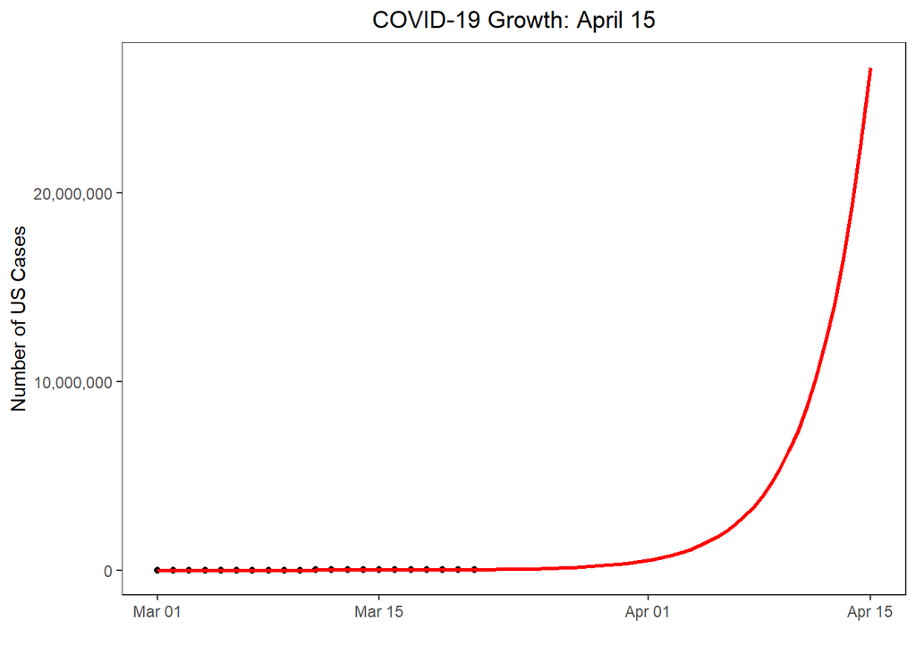

```r
g5 = ggplot(data,aes(x=`Date`,y=`Number of US Cases`)) +
  geom_point(size=1.5) +
  geom_smooth(method=lm,se=F,fullrange=T,color='red',
              formula =
                y~exp(fit$coefficients[1] +
                        fit$coefficients[2] * as.numeric(as_date(x) - min(data$`Date`)))) +
  xlab('') +
  xlim(c(ymd('0000-03-01'),ymd('0000-04-15'))) +
  ggtitle('COVID-19 Growth: April 15') +
  theme_bw() +
  theme(panel.grid = element_blank(),
        plot.title = element_text(hjust = 0.5)) +
  scale_y_continuous(labels = function(x) format(x, scientific = F,big.mark=','))

g5
```

Of course, we know the rate of growth will have to slow down at *some* point.

The question is… when will it slow down? And by how much?

What degree of effect will our social distancing have? Could it already be working, but proliferated testing is creating an illusion of sustained exponential growth? Or is an even greater surge in growth yet to come?

These are the million dollar questions right now, and there isn’t enough information to generate even moderately definitive answers.

All we know is that, so far, this model has been a very good fit for the number of reported cases over the last three weeks. We’ve stayed on the virtually the same exponential track consistently since March 1.